# Exam 1

## Exam 1

#### Metainformation

1. | Tag | Value |
   | --- | --- |
   | `file` | Descriptive-statistics_vufsw-correlation-1351-nl_vufsw-correlation-1351-nl |
   | `name` | vufsw-correlation-1351-nl |
   | `section` | descriptive statistics/summary statistics/bivariate statistics/correlation |
   | `type` | schoice |
   | `solution` | FALSE, FALSE, TRUE, FALSE |
   | `ID` | 0ab04 |
   | `Type` | interpreting output |
   | `Program` | NA |
   | `Language` | Dutch |
   | `Level` | statistical literacy |

#### Question

   Sommige whatsapp gebruikers kunnen hun whatsapp niet meer met rust laten, bij hen is het compulsief (dwangmatig) gedrag geworden. Dit is mogelijk gerelateerd aan het gevoel niets te mogen missen, ofwel de ‘fear-of-missing-out’ (FOMO). Het databestand van Esam, Groot, Smits en Verhelst (2016) is verzameld om deze relatie te onderzoeken. De data zijn verzameld via een online survey onder 204 respondenten.

   In de onderstaande partiële correlatiematrix, inclusief zero-order correlaties, is onderzocht of er een verband bestaat tussen compulsief Whatsapp gebruik en ‘fear-of-missing-out’ en of deze relatie verandert wanneer je de invloed van opleidingsniveau constant houdt. Er geldt Y = COMPULSIVE (een hogere score betekent meer compulsief Whatsapp gebruik), X = FOMO (een hogere score betekent een sterker gevoel van ‘fear-of-missing-out’), en de derde variabele is EDUCATION (opleidingsniveau: een hogere score betekent een hoger opleidingsniveau).

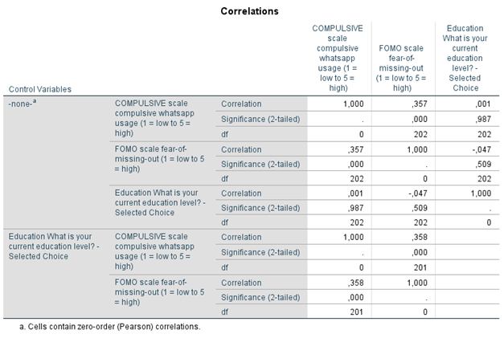

   Hoe moeten we de correlatie tussen FOMO en Whatsapp-gebruik inhoudelijk interpreteren?  
   1: Hoe hoger de ‘fear-of-missing-out’, des te compulsiever het Whatsapp-gebruik  
   2: Hoe lager de ‘fear-of-missing-out’, des te minder compulsief het Whatsapp-gebruik
   1. **FALSE:** Alleen uitspraak 1 klopt
   2. **FALSE:** Alleen uitspraak 2 klopt
   3. **TRUE:** Beide uitspraken kloppen
   4. **FALSE:** Geen van beide uitspraken klopt
   1. False
   2. False
   3. True
   4. False